# Urban Sound Classification

Menghong Han

## Description

This dataset contains 8732 labeled sound excerpts (<=4s) of urban sounds from 10 classes: air_conditioner, car_horn, children_playing, dog_bark, drilling, enginge_idling, gun_shot, jackhammer, siren, and street_music. The classes are drawn from the urban sound taxonomy. All excerpts are taken from field recordings uploaded to www.freesound.org. The files are pre-sorted into ten folds (folders named fold1-fold10) to help in the reproduction of and comparison with the automatic classification results reported in the article above.

In addition to the sound excerpts, a CSV file containing metadata about each excerpt is also provided.

## Structure

1. Descriptive data analysis
2. Feature Extraction
3. Dataset Building
4. Model Selection
5. Evaluation
6. Result Analysis

```python
# Basic Libraries

import pandas as pd
import numpy as np
import matplotlib.pyplot as plt
%matplotlib inline
import seaborn as sns
import os
import sys
from tqdm import tqdm
import IPython
import math
import pickle
import random
from datetime import datetime
```

```python
# Libraries for Classification and building Models


from keras import backend as keras_backend
from keras.models import Sequential, load_model
from keras.layers import Dense, SpatialDropout2D, Activation, Conv2D, MaxPooling2D, BatchNormalization, GlobalAveragePooling2D, LeakyReLU
from keras.optimizers import Adam
from keras.utils import to_categorical
from keras.callbacks import ModelCheckpoint
from keras.regularizers import l2

from sklearn.preprocessing import LabelEncoder
from sklearn.metrics import classification_report, confusion_matrix
```

```python
# Project Specific Libraries

import os
import librosa
import librosa.display
import glob
import skimage
```

```python
# import data
df = pd.read_csv("UrbanSound8K.csv")
df.shape
```

```
(8732, 8)
```

```python
# show the data
df.head()
```

|  | slice_file_name | fsID | start | end | salience | fold | classID | class |
| --- | --- | --- | --- | --- | --- | --- | --- | --- |
| 0 | 100032-3-0-0.wav | 100032 | 0.0 | 0.317551 | 1 | 5 | 3 | dog_bark |
| 1 | 100263-2-0-117.wav | 100263 | 58.5 | 62.500000 | 1 | 5 | 2 | children_playing |
| 2 | 100263-2-0-121.wav | 100263 | 60.5 | 64.500000 | 1 | 5 | 2 | children_playing |
| 3 | 100263-2-0-126.wav | 100263 | 63.0 | 67.000000 | 1 | 5 | 2 | children_playing |
| 4 | 100263-2-0-137.wav | 100263 | 68.5 | 72.500000 | 1 | 5 | 2 | children_playing |

### Column Names

slicefilename: The name of the audio file. The name takes the following format: [fsID]-[classID]-[occurrenceID]-[sliceID].wav, where: [fsID] = the Freesound ID of the recording from which this excerpt (slice) is taken [classID] = a numeric identifier of the sound class (see description of classID below for further details) [occurrenceID] = a numeric identifier to distinguish different occurrences of the sound within the original recording [sliceID] = a numeric identifier to distinguish different slices taken from the same occurrence

fsID: The Freesound ID of the recording from which this excerpt (slice) is taken

start The start time of the slice in the original Freesound recording

end: The end time of slice in the original Freesound recording

salience: A (subjective) salience rating of the sound. 1 = foreground, 2 = background.

fold: The fold number (1-10) to which this file has been allocated.

classID: A numeric identifier of the sound class: 0 = airconditioner 1 = carhorn 2 = childrenplaying 3 = dogbark 4 = drilling 5 = engineidling 6 = gunshot 7 = jackhammer 8 = siren 9 = street_music

class: The class name: airconditioner, carhorn, childrenplaying, dogbark, drilling, engineidling, gunshot, jackhammer, siren, street_music.

### Digital audio properties

The main features that describe digital audio -which we want to analyze on this notebook- are:

Channels: number of audio channels (mono/stereo). Sample Rate: samples per second expressed in kilohertz (kHz); related to audio quality. Bit Depth: equal to resolution in images, describes level of detail. Duration: length of the sound over time. Data of different audio properties will also have different shape or structure. Our first task is to determine how are this different audio properties distributed among the dataset and evaluate how we may normalize them, for example, by conversion.

```python
# unzip and import the record files
import zipfile
import os
files = zipfile.ZipFile('urbansound8k.zip', 'r')
files.extractall('urbansound8k')
files.close()
```

## 1. Descriptive data analysis

#### Fold Distribution

```python
df["fold"].value_counts()
```

```
4     990
5     936
3     925
2     888
1     873
7     838
10    837
6     823
9     816
8     806
Name: fold, dtype: int64
```

#### Classifier Distribution

```python
appended = []
for i in range(1,11):
    appended.append(df[df.fold == i]['class'].value_counts())

class_distribution = pd.DataFrame(appended)
class_distribution = class_distribution.reset_index()
class_distribution['index'] = ["fold"+str(x) for x in range(1,11)]
class_distribution
```

|  | index | jackhammer | children_playing | street_music | dog_bark | air_conditioner | drilling | engine_idling | siren | car_horn | gun_shot |
| --- | --- | --- | --- | --- | --- | --- | --- | --- | --- | --- | --- |
| 0 | fold1 | 120 | 100 | 100 | 100 | 100 | 100 | 96 | 86 | 36 | 35 |
| 1 | fold2 | 120 | 100 | 100 | 100 | 100 | 100 | 100 | 91 | 42 | 35 |
| 2 | fold3 | 120 | 100 | 100 | 100 | 100 | 100 | 107 | 119 | 43 | 36 |
| 3 | fold4 | 120 | 100 | 100 | 100 | 100 | 100 | 107 | 166 | 59 | 38 |
| 4 | fold5 | 120 | 100 | 100 | 100 | 100 | 100 | 107 | 71 | 98 | 40 |
| 5 | fold6 | 68 | 100 | 100 | 100 | 100 | 100 | 107 | 74 | 28 | 46 |
| 6 | fold7 | 76 | 100 | 100 | 100 | 100 | 100 | 106 | 77 | 28 | 51 |
| 7 | fold8 | 78 | 100 | 100 | 100 | 100 | 100 | 88 | 80 | 30 | 30 |
| 8 | fold9 | 82 | 100 | 100 | 100 | 100 | 100 | 89 | 82 | 32 | 31 |
| 9 | fold10 | 96 | 100 | 100 | 100 | 100 | 100 | 93 | 83 | 33 | 32 |

```python
df['class'].value_counts(normalize=True)
```

```
drilling            0.114521
jackhammer          0.114521
street_music        0.114521
engine_idling       0.114521
children_playing    0.114521
dog_bark            0.114521
air_conditioner     0.114521
siren               0.106390
car_horn            0.049130
gun_shot            0.042831
Name: class, dtype: float64
```

There are two classes (car_horn, gun_shot) which have a bit less than half amount of entries compared to other 8 classes. It doesn’t look like it is severely unbalanced, so for the moment, I have decided not to consider any data augmentation for these two minority classes.

## 2. Feature Extraction

Feature extraction is used to convert the acoustic signal into a sequence of acoustic feature vectors that carry a good representation of input speech signal. The idea is to reduce the ten thousands of data points in each file into a much smaller set of features of fixed number.

An important aspect discussed is the features used for audio recognition: raw audio data, spectograms, MFCC, mel-spectograms and log-mel spectograms where used at first, with MFCC, mel-spectograms and log-mel spectograms being the best performant. Later, the combination of different audition features got better results, combining the ones mentioned with others like chroma, tonnentz, spectral contrast and others. Over the last years some researches with 1D convolution and raw audio data appeared, achieving better results than other researches that used 2D convolutions.

### 2.1 Mel-Frequency Cepstral Coefficients (MFCCs)

MFCCs has been the most common approach for the last years as it has proved to perform much better than normal spectrograms. MFCC takes into account human perception for sensitivity at appropriate frequencies by converting the conventional frequency to Mel Scale (which is not linear but logarithmic).

To generate MFCCs a Discrete Cosine Transform (DCT) is applied to the filter banks obtained in the last process, retaining a number of the resulting coefficients while the rest are discarded.

This is an MFCC plot from a random audio sample in our dataset:

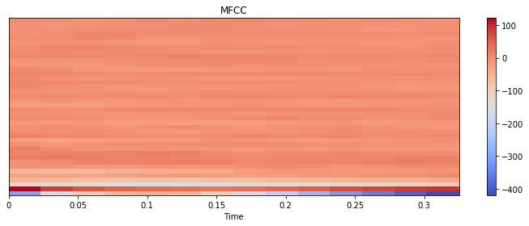

```python
#MFCC
y,sr=librosa.load("urbansound8k/fold5/100032-3-0-0.wav")
mfccs = librosa.feature.mfcc(y, sr, n_mfcc=40)

import matplotlib.pyplot as plt
plt.figure(figsize=(10,4))
librosa.display.specshow(mfccs, x_axis='time')
plt.colorbar()
plt.title('MFCC')
plt.tight_layout()
```

### 2.2 MEL- Spectrogram

Although MFCCs work very well, there's still a problem with it: Discrete Cosine Transform (DCT) is used to decorrelate filter bank coefficients (a process referred to as "whitening"). DCT, as a linear transform, will discard some information from the original signal (something we don't really want to happen). Whitening was required for models that where more susceptible to highly correlated input (like Gaussian Mixture Models), but as deep neural networks are much less susceptible we could easily eliminate DCT from the pipeline.

Once the filter banks had been computed they are scaled to the MEL scale to obtain the MEL-Scaled filter banks. This is how a MEL Spectrogram looks:

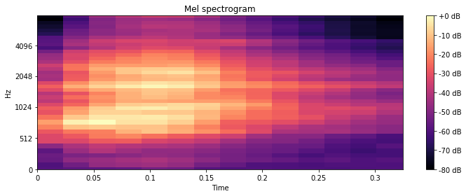

```python
#Melspectrogram
melspectrogram =librosa.feature.melspectrogram(y=y, sr=sr, n_mels=40,fmax=8000)
plt.figure(figsize=(10,4))
librosa.display.specshow(librosa.power_to_db(melspectrogram,ref=np.max),y_axis='mel', fmax=8000,x_axis='time')
plt.colorbar(format='%+2.0f dB')
plt.title('Mel spectrogram')
plt.tight_layout()
```

### 2.3 Chroma Short Time Fourier Transform (stft)

A spectrogram is a visual representation of the spectrum of frequencies of a signal as it varies with time. The interesting aspect of this approach is that you can treat audio signals as images, and thus, use it to feed a 2-dimensional convolutional layer: directly, by using the image of a spectrogram or (usually better) using the coefficients values that describe a spectrogram.

The drawback is that a spectrogram is spectrograms use a linear frequency scaling, so each frequency bin is spaced the equal number of Hertz apart. This is not how the human auditory system work, our brain tends to separate sound components in a logarithmic scale, so the normal spectrogram does not represent sound exactly as we listen to it.

Chroma features are an interesting and powerful representation for music audio in which the entire spectrum is projected onto 12 bins representing the 12 distinct semitones (or chroma) of the musical octave.

Chroma short time fourier transform means compute a chromagram from a waveform or power spectrogram

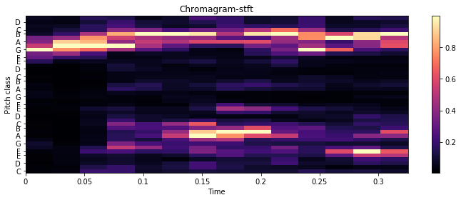

```python
# Chroma_stft
chroma_stft=librosa.feature.chroma_stft(y=y, sr=sr,n_chroma=40)
plt.figure(figsize=(10,4))
librosa.display.specshow(chroma_stft, y_axis='chroma', x_axis='time')
plt.colorbar()
plt.title('Chromagram-stft')
plt.tight_layout()
```

Based on the feature extracting methods listed above, in this report, I'll try to combine "MFCC", "Melspectrogram", "Chroma_stft" together to extract various feature with Librosa library.

```python
#feature set

y,sr=librosa.load("urbansound8k/fold5/100032-3-0-0.wav")
mfccs = np.mean(librosa.feature.mfcc(y, sr, n_mfcc=40).T,axis=0)
melspectrogram = np.mean(librosa.feature.melspectrogram(y=y, sr=sr, n_mels=40,fmax=8000).T,axis=0)
chroma_stft=np.mean(librosa.feature.chroma_stft(y=y, sr=sr,n_chroma=40).T,axis=0)
# tonnetz = np.mean(librosa.feature.tonnetz(y=librosa.effects.harmonic(X),sr=sr).T,axis=0)
# melspectrogram.shape,chroma_stft.shape,contrast.shape,tonnetz.shape,mfccs.shape
mfccs.shape,melspectrogram.shape,chroma_stft.shape
```

```
((40,), (40,), (40,))
```

## 3. Dataset Building

```python
#stacking and reshaping
features=np.reshape(np.vstack((mfccs,melspectrogram,chroma_stft)),(40,3))
features.shape
```

```
(40, 3)
```

```python
#preprocessing using entire feature set
x_train=[]
x_test=[]
y_train=[]
y_test=[]

path="urbansound8k/fold"
for i in tqdm(range(len(df))):
    fold_no=str(df.iloc[i]["fold"])
    file=df.iloc[i]["slice_file_name"]
    label=df.iloc[i]["classID"]
    filename=path+fold_no+"/"+file
    y,sr=librosa.load(filename)
    mfccs = np.mean(librosa.feature.mfcc(y, sr, n_mfcc=40).T,axis=0)
    melspectrogram = np.mean(librosa.feature.melspectrogram(y=y, sr=sr, n_mels=40,fmax=8000).T,axis=0)
    chroma_stft=np.mean(librosa.feature.chroma_stft(y=y, sr=sr,n_chroma=40).T,axis=0)
    features=np.reshape(np.vstack((mfccs,melspectrogram,chroma_stft)),(40,3))
    if(fold_no!='10'):
      x_train.append(features)
      y_train.append(label)
    else:
      x_test.append(features)
      y_test.append(label)
```

```python
len(x_train)+len(x_test)
```

```
8732
```

```python
x=x_train+x_test
y=y_train+y_test
```

```python
#converting the lists into numpy arrays
x=np.array(x)
y=np.array(y)
x.shape,y.shape
```

```
((8732, 40, 3), (8732,))
```

```python
#reshaping into 2d to save in csv format
x_2d=np.reshape(x,(x.shape[0],x.shape[1]*x.shape[2]))
x_2d.shape

#saving the data numpy arrays
np.savetxt("x.csv", x_2d, delimiter=",")
np.savetxt("y.csv",y,delimiter=",")
```

```python
x_2d.shape
```

```
(8732, 120)
```

## 4. Model Selection

I've researched papers and projects on github and I found many models are used on this dataset. For instance, Justin Salamon et al. used SVM in "A Dataset and Taxonomy for Urban Sound Research" and they also used deep CNN in"Deep Convolutional Neural Networks and Data Augmentation for Environmental Sound Classification"; Aqibsaeed used NN, CNN and RNN; Sajjad Abdoli et al. used 1D CNN in "End-to-End Environmental Sound Classification using a 1DConvolutional Neural Network".

Most of them used quite simple networks compared to what we are used for image classification, where instead of using models like ResNets with 50+ layers, you can see models with 4 or 8 layers, some of them with no dense layers before the softmax output. The accuracy of the above models are all between 70%-90%.

In this notebook I want to build simple yet effective 2D convolutional model to solve this multi-class classification problem.

### Train & test data split

```python
indexes = []
total = len(df)
indexes = list(range(0, total))

# Randomize indexes
random.shuffle(indexes)

# Divide the indexes into Train and Test
test_split_pct = 20
split_offset = math.floor(test_split_pct * total / 100)

# Split the data
test_split_idx = indexes[0:split_offset]
train_split_idx = indexes[split_offset:total]


# Split the features with the same indexes
X_test = np.take(x, test_split_idx, axis=0)
y_test = np.take(y, test_split_idx, axis=0)
X_train = np.take(x, train_split_idx, axis=0)
y_train = np.take(y, train_split_idx, axis=0)

# Also split metadata
test = df.iloc[test_split_idx]
train = df.iloc[train_split_idx]

# Print status
print("Test split: {} \t\t Train split: {}".format(len(test), len(train)))
print("X test shape: {} \t X train shape: {}".format(X_test.shape, X_train.shape))
print("y test shape: {} \t\t y train shape: {}".format(y_test.shape, y_train.shape))
```

```
Test split: 1746 		 Train split: 6986
X test shape: (1746, 40, 3) 	 X train shape: (6986, 40, 3)
y test shape: (1746,) 		 y train shape: (6986,)
```

```python
#converting to one hot
from keras.utils.np_utils import to_categorical
y_train = to_categorical(y_train, num_classes=10)
y_test = to_categorical(y_test, num_classes=10)
y_train.shape,y_test.shape
```

```
((6986, 10), (1746, 10))
```

```python
#reshaping to 2D
X_train=np.reshape(X_train,(X_train.shape[0], 40,3))
X_test=np.reshape(X_test,(X_test.shape[0], 40,3))
X_train.shape,X_test.shape
```

```
((6986, 40, 3), (1746, 40, 3))
```

```python
#reshaping to shape required by CNN
X_train=np.reshape(X_train,(X_train.shape[0], 40,3,1))
X_test=np.reshape(X_test,(X_test.shape[0], 40,3,1))
X_train.shape,X_test.shape
```

```
((6986, 40, 3, 1), (1746, 40, 3, 1))
```

### Convolutional layers and filter amounts:

each convolutional layer will learn different features from the training data. The first layers will always learn more low level features (like lines and dots on an image, for example), while the following layers will learn more high-level patterns (basic shapes). The more complex the data is in means of patterns, the more convolutional layers that will be required learn them. On the other hand, there will always be less low-level patterns and more high-level patters (formed by combinations of those lower level patterns), that's why we keep increasing the amount of filters as we add convolutional layers to the network.

### Kernel sizes:

I'm using 5x5 kernel sizes as the smallest size and the size should be odd.

### MaxPooling:

a common technique to downsample our data reducing dimensionality, if not familiarized have a look at this article from computersciencewiki.org.

### Dense (softmax output):

the final layer containing the softmax output that will provide the classification probabilities for the input data.

```python
from keras import Sequential
from keras.layers import Dense,Conv2D,MaxPooling2D,Flatten,Dropout

#forming model
model=Sequential()

#adding layers and forming the model
model.add(Conv2D(64,kernel_size=5,strides=1,padding="Same",activation="relu",input_shape=(40,3,1)))
model.add(MaxPooling2D(padding="same"))

model.add(Conv2D(128,kernel_size=5,strides=1,padding="same",activation="relu"))
model.add(MaxPooling2D(padding="same"))
model.add(Dropout(0.3))

model.add(Flatten())

model.add(Dense(256,activation="relu"))
model.add(Dropout(0.3))

model.add(Dense(512,activation="relu"))
model.add(Dropout(0.3))

model.add(Dense(10,activation="softmax"))
```

```python
#compiling
model.compile(optimizer="adam",loss="categorical_crossentropy",metrics=["accuracy"])

#training the model
model.fit(X_train,y_train,batch_size=50,epochs=30,validation_data=(X_test,y_test))
```

```
Train on 6986 samples, validate on 1746 samples
```

```
<keras.callbacks.callbacks.History at 0x7f66204c4310>
```

## 5. Evaluation

```python
#train and test loss and scores respectively
train_loss_score=model.evaluate(X_train,y_train)
test_loss_score=model.evaluate(X_test,y_test)
print(train_loss_score)
print(test_loss_score)
```

```
[0.11292129374065749, 0.96722012758255]
[0.2310967371294452, 0.9278350472450256]
```